# Multivariate TS Models (ARIMAX/SARIMAX/VAR)

## Literature Review

In analyzing the temporal dynamics of the U.S. freight transportation industry, key variables emerge as critical factors shaping its trajectory. Economic indicators, encompassing metrics like GDP growth, consumer spending, and industrial production, serve as pivotal markers of overall economic activity. These indicators not only influence freight transportation demand but also offer insights into broader economic trends. Additionally, fuel prices wield significant influence, affecting operating costs and modal choice decisions within the transportation sector. Research underscores the impact of fuel price fluctuations on transportation costs, suggesting their inclusion as exogenous variables in ARIMAX models to enhance freight volume forecasts.

When considering modeling approaches, both ARIMAX and VAR models offer distinct advantages for capturing the complexities of freight transportation dynamics. ARIMAX models are well-suited for incorporating economic indicators, fuel prices, and infrastructure investment as variables. Leveraging their autoregressive and exogenous components, ARIMAX models can effectively account for temporal patterns and external influences, thereby improving the accuracy of freight volume forecasts over time. On the other hand, VAR models excel in analyzing the dynamic relationships among multiple variables. They provide a versatile framework for examining the simultaneous effects of economic indicators, fuel prices, regulatory changes, and technological advancements on freight transportation dynamics. With their capacity to capture intricate interactions and feedback mechanisms, VAR models offer valuable insights into the evolving landscape of the freight transportation industry.

For the VAR model, the analysis delves into three distinct sets of variables within the air cargo industry to uncover their interrelationships and implications. Firstly, it examines the connections between Air Cargo (Domestic), Air Cargo (International), Fuel Price, and the Transportation Services Index (TSI). This investigation aims to discern whether fluctuations in air cargo volumes, both domestically and internationally, correlate with changes in fuel prices and TSI, thereby providing insights into the broader drivers of the air cargo industry.

Secondly, the analysis focuses on the relationship between Air Cargo (Domestic), Air Cargo (International), and Employment. By exploring the mutual influence between air cargo volumes and employment levels. Understanding these dynamics is crucial for grasping the industry’s labor market dynamics and its broader economic implications.

Lastly, the analysis considers the dynamics between GDP, Revenue, and Employment within the air industry. By examining the interplay between these key economic indicators, it aims to uncover the industry’s economic performance and its effects on employment trends. This exploration provides valuable insights into the industry’s contribution to the broader economy and its role in shaping employment patterns.

## Define Models

### ARIMAX: UPS Stock Price ~ Covid New Cases (Weekly)

```r
#  ARIMAX: ups stock price and covid new cases (weekly)
# get the weekly stock price of ups
ups <- getSymbols("UPS",auto.assign = FALSE, from = "2020-01-01", to = "2023-05-15",src="yahoo")
ups=data.frame(ups)
ups <- data.frame(ups,rownames(ups))
colnames(ups)[7] = "date"
ups$date<-as.Date(ups$date,"%Y-%m-%d")
ups <- ups[seq(1, nrow(ups), by = 5), ]

# get the weekly covid new cases
covid <- read.csv("data/clean_data/covid.csv",header =TRUE, sep = ',')
covid <- subset(covid, select = c(date, new_cases_per_million))
covid <- na.omit(covid)
covid <- head(covid, -6)

# combine the data
ups_covid <- data.frame("UPS"=ups$UPS.Adjusted, "COVID"=covid$new_cases_per_million)
#(head(ups_covid))

# Convert to a Time Series Component
ups_covid_ts <- ts(ups_covid, start = decimal_date(as.Date("2000-01-02", format = "%Y-%m-%d")), frequency = 52)

head(ups_covid_ts)
```

```
Time Series:
Start = 2000.00273224044
End = 2000.09888608659
Frequency = 52
               UPS COVID
2000.003 101.86604 0.000
2000.022 101.98815 0.000
2000.041 103.45346 0.000
2000.060 101.75266 0.021
2000.080  90.29176 0.006
2000.099  89.94286 0.033
```

```r
VARselect(ups_covid_ts, lag.max=10, type="both")
```

```
$selection
AIC(n)  HQ(n)  SC(n) FPE(n)
     3      3      3      3

$criteria
                  1            2            3            4            5
AIC(n) 1.741863e+01 1.642378e+01 1.618952e+01 1.623171e+01 1.624929e+01
HQ(n)  1.748106e+01 1.651743e+01 1.631439e+01 1.638780e+01 1.643660e+01
SC(n)  1.757239e+01 1.665441e+01 1.649703e+01 1.661610e+01 1.671057e+01
FPE(n) 3.671328e+07 1.357644e+07 1.074212e+07 1.120680e+07 1.140832e+07
                  6            7            8            9           10
AIC(n) 1.625502e+01 1.630247e+01 1.630624e+01 1.633906e+01 1.634971e+01
HQ(n)  1.647355e+01 1.655222e+01 1.658720e+01 1.665124e+01 1.669311e+01
SC(n)  1.679318e+01 1.691751e+01 1.699815e+01 1.710786e+01 1.719539e+01
FPE(n) 1.147772e+07 1.204083e+07 1.209318e+07 1.250566e+07 1.265064e+07
```

```r
summary(vars::VAR(ups_covid_ts, p=3, type='both'))
```

```
VAR Estimation Results:
=========================
Endogenous variables: UPS, COVID
Deterministic variables: both
Sample size: 167
Log Likelihood: -1806.747
Roots of the characteristic polynomial:
0.9694 0.6912 0.6912 0.6045 0.6045 0.3295
Call:
vars::VAR(y = ups_covid_ts, p = 3, type = "both")


Estimation results for equation UPS:
====================================
UPS = UPS.l1 + COVID.l1 + UPS.l2 + COVID.l2 + UPS.l3 + COVID.l3 + const + trend

          Estimate Std. Error t value Pr(>|t|)
UPS.l1    0.922420   0.079311  11.630   <2e-16 ***
COVID.l1  0.002424   0.001095   2.213   0.0283 *
UPS.l2    0.084132   0.108242   0.777   0.4382
COVID.l2 -0.004577   0.001932  -2.369   0.0190 *
UPS.l3   -0.056045   0.079195  -0.708   0.4802
COVID.l3  0.002559   0.001090   2.349   0.0201 *
const     6.383749   2.925004   2.182   0.0305 *
trend     0.012088   0.016784   0.720   0.4725
---
Signif. codes:  0 '***' 0.001 '**' 0.01 '*' 0.05 '.' 0.1 ' ' 1


Residual standard error: 6.93 on 159 degrees of freedom
Multiple R-Squared: 0.9605, Adjusted R-squared: 0.9588
F-statistic: 552.9 on 7 and 159 DF,  p-value: < 2.2e-16


Estimation results for equation COVID:
======================================
COVID = UPS.l1 + COVID.l1 + UPS.l2 + COVID.l2 + UPS.l3 + COVID.l3 + const + trend

           Estimate Std. Error t value Pr(>|t|)
UPS.l1     -1.65029    5.11684  -0.323   0.7475
```

[output cut: 11 more lines]

```
Residual standard error: 447.1 on 159 degrees of freedom
Multiple R-Squared: 0.9645, Adjusted R-squared: 0.9629
F-statistic: 616.4 on 7 and 159 DF,  p-value: < 2.2e-16



Covariance matrix of residuals:
         UPS    COVID
UPS    48.02    400.9
COVID 400.89 199870.1

Correlation matrix of residuals:
         UPS  COVID
UPS   1.0000 0.1294
COVID 0.1294 1.0000
```

### ARIMAX: Canada Freight Value ~ Fuel Price + TSI (Monthly)

```r
#  ARIMAX: Canada Freight Value and Fuel Price, TSI (monthly)
# get the canada freight monthly value
canada <- read.csv("data/clean_data/24monthly_canada_freight.csv")
canada <- canada[,c("Date","Value")]

# get the fuel monthly price
fuel <- read.csv("data/clean_data/34monthly_fuel_prices.csv")
# remove the dollar sign
fuel$Diesel <- as.numeric(gsub("\\$", "", fuel$Diesel))
fuel$Jet.Fuel <- as.numeric(gsub("\\$", "", fuel$Jet.Fuel))
# select the same start data
fuel1 <- fuel[73:(nrow(fuel)-6),]

# get the TSI monthly data
tsi <- read.csv("data/clean_data/35monthly_TSI.csv")
tsi1 <- tsi[73:nrow(tsi),]

# combine the data
canada_value <- data.frame("Canada_value"=canada$Value, "Fuel"=fuel1$Diesel, "TSI"=tsi1$Transportation.Services.Index...Freight)
#(head(canada_value))

canada_value_ts <- ts(canada_value, start = decimal_date(as.Date("2006-01-01", format = "%Y-%m-%d")), frequency = 12)

head(canada_value_ts)
```

```
         Canada_value  Fuel   TSI
Jan 2006     43.47682 246.7 112.7
Feb 2006     42.49097 247.5 111.8
Mar 2006     47.70424 255.9 112.3
Apr 2006     44.39409 272.8 111.5
May 2006     46.93539 289.7 113.8
Jun 2006     46.93349 289.8 113.2
```

```r
VARselect(canada_value_ts, lag.max=10, type="both")
```

```
$selection
AIC(n)  HQ(n)  SC(n) FPE(n)
     5      2      2      5

$criteria
                 1           2           3           4           5           6
AIC(n)    8.691136    8.464988    8.494859    8.518167    8.436699    8.473295
HQ(n)     8.793074    8.628090    8.719124    8.803595    8.783290    8.881049
SC(n)     8.942905    8.867819    9.048752    9.223121    9.292715    9.480372
FPE(n) 5950.138371 4746.328750 4891.327230 5008.589137 4619.448418 4795.660373
                 7           8           9          10
AIC(n)    8.527247    8.535385    8.493115    8.509458
HQ(n)     8.996163    9.065465    9.084357    9.161864
SC(n)     9.685385    9.844585    9.953376   10.120781
FPE(n) 5067.263805 5116.249960 4913.696808 5006.248630
```

```r
summary(vars::VAR(canada_value_ts, p=2, type='both'))
```

```
VAR Estimation Results:
=========================
Endogenous variables: Canada_value, Fuel, TSI
Deterministic variables: both
Sample size: 203
Log Likelihood: -1701.185
Roots of the characteristic polynomial:
0.9501 0.9078 0.6348 0.4929 0.2956 0.0797
Call:
vars::VAR(y = canada_value_ts, p = 2, type = "both")


Estimation results for equation Canada_value:
=============================================
Canada_value = Canada_value.l1 + Fuel.l1 + TSI.l1 + Canada_value.l2 + Fuel.l2 + TSI.l2 + const + trend

                 Estimate Std. Error t value Pr(>|t|)
Canada_value.l1  0.292011   0.080946   3.607 0.000393 ***
Fuel.l1          0.091413   0.014954   6.113 5.23e-09 ***
TSI.l1           0.460503   0.150331   3.063 0.002499 **
Canada_value.l2  0.197264   0.080124   2.462 0.014686 *
Fuel.l2         -0.061655   0.014576  -4.230 3.59e-05 ***
TSI.l2          -0.311907   0.146791  -2.125 0.034859 *
const           -1.899300   4.800557  -0.396 0.692802
trend           -0.004806   0.009716  -0.495 0.621406
---
Signif. codes:  0 '***' 0.001 '**' 0.01 '*' 0.05 '.' 0.1 ' ' 1


Residual standard error: 3.178 on 195 degrees of freedom
Multiple R-Squared: 0.811,  Adjusted R-squared: 0.8042
F-statistic: 119.5 on 7 and 195 DF,  p-value: < 2.2e-16


Estimation results for equation Fuel:
=====================================
Fuel = Canada_value.l1 + Fuel.l1 + TSI.l1 + Canada_value.l2 + Fuel.l2 + TSI.l2 + const + trend

                Estimate Std. Error t value Pr(>|t|)
Canada_value.l1 -0.26079    0.39222  -0.665    0.507
```

[output cut: 35 more lines]

```
F-statistic:  1781 on 7 and 195 DF,  p-value: < 2.2e-16



Covariance matrix of residuals:
             Canada_value    Fuel   TSI
Canada_value       10.102  21.021 1.542
Fuel               21.021 237.186 2.333
TSI                 1.542   2.333 2.442

Correlation matrix of residuals:
             Canada_value    Fuel     TSI
Canada_value       1.0000 0.42944 0.31040
Fuel               0.4294 1.00000 0.09693
TSI                0.3104 0.09693 1.00000
```

### VAR: Air Cargo(Domestic) ~ Air Cargo(International) + Fuel Price + TSI (Monthly)

```r
#  VAR: Air Cargo and Fuel Price, TSI (monthly)
# get the cargo data
cargo <- read.csv("data/clean_data/Monthly_air_revenue.csv")
cargo$International <- cargo$U.S..Air.Carrier.Cargo..millions.of.revenue.ton.miles....International/1000000000
cargo$Domestic <- cargo$U.S..Air.Carrier.Cargo..millions.of.revenue.ton.miles....Domestic/1000000000
cargo <- cargo[4:(nrow(cargo)-8),]

# get the fuel monthly price
fuel <- read.csv("data/clean_data/34monthly_fuel_prices.csv")
# remove the dollar sign
fuel$Diesel <- as.numeric(gsub("\\$", "", fuel$Diesel))
fuel$Jet.Fuel <- as.numeric(gsub("\\$", "", fuel$Jet.Fuel))
# select the same start data
fuel2 <- fuel[37:(nrow(fuel)-6),]

# get the TSI monthly data
tsi <- read.csv("data/clean_data/35monthly_TSI.csv")
tsi2 <- tsi[37:nrow(tsi),]

# combine the data
revenue_ <- data.frame("Domestic"=cargo$Domestic, "International"=cargo$International, "Fuel"=fuel2$Jet.Fuel, "TSI"=tsi2$Transportation.Services.Index...Freight)
#(head(revenue_))

revenue_ts <- ts(revenue_, start = decimal_date(as.Date("2003-01-01", format = "%Y-%m-%d")), frequency = 12)

head(revenue_ts)
```

```
         Domestic International  Fuel   TSI
Jan 2003 1.177785      1.395876  88.7 104.2
Feb 2003 1.079561      1.366617 105.5 103.4
Mar 2003 1.233953      1.691870  89.3 103.9
Apr 2003 1.208202      1.524837  74.3 104.0
May 2003 1.243021      1.489449  71.4 103.0
Jun 2003 1.207785      1.473214  74.8 102.9
```

### VAR: Employment ~ Air Cargo(Domestic) + Air Cargo(International) (Monthly)

```r
#  VAR: Employment and Air Cargo (monthly)
# get the employment data
employment <- read.csv("data/clean_data/32monthly_employment.csv")
employment <- employment[,c("Date","Transportation.Employment...Air.Transportation")]

# get the cargo data
cargo <- read.csv("data/clean_data/Monthly_air_revenue.csv")
cargo$International <- cargo$U.S..Air.Carrier.Cargo..millions.of.revenue.ton.miles....International/1000000000
cargo$Domestic <- cargo$U.S..Air.Carrier.Cargo..millions.of.revenue.ton.miles....Domestic/1000000000
cargo1 <- cargo[28:(nrow(cargo)-8),]

# combine the data
emp_ <- data.frame("Employment"=employment$Transportation.Employment...Air.Transportation, "International"=cargo1$International, "Domestic"=cargo1$Domestic)
#(head(emp_))

emp_ts <- ts(emp_, start = decimal_date(as.Date("2005-01-01", format = "%Y-%m-%d")), frequency = 12)

head(emp_ts)
```

```
         Employment International Domestic
Jan 2005     505200      1.696944 1.280516
Feb 2005     503400      1.561959 1.253130
Mar 2005     504200      1.958162 1.469765
Apr 2005     507300      2.078222 1.226824
May 2005     507800      1.925489 1.261165
Jun 2005     508300      1.981247 1.351714
```

### VAR: GDP ~ Revenue + Employment (Air, Yearly)

```r
#  VAR: Air GDP, Revenue and Employment (yearly)
# get the yearly GDP of air
gdp <- read.csv("data/clean_data/31GDP.csv")
# Group by Year and Mode, calculate the sum of GDP within each group
gdp <- gdp %>%
  filter(Mode =='Air')%>%
  group_by(Year) %>%
  summarize(Value = sum(Current....billions., na.rm = TRUE))

# get the air revenue
air <- read.csv("data/clean_data/33revenue.csv")
air <- air[air$Mode=="Air carrier, domestic",c("Year","Value")]
air <- air[order(air$Year), ]
air <- air[13:nrow(air),]

# get the air employment
employment <- read.csv("data/clean_data/32monthly_employment.csv")
employment <- employment[,c("Date","Transportation.Employment...Air.Transportation")]
employment$Date <- as.POSIXct(employment$Date, format = "%m/%d/%Y %I:%M:%S %p")
employment$Year <- format(employment$Date, "%Y")
employment <- employment %>%
              group_by(Year) %>%
              summarize(Value = sum(Transportation.Employment...Air.Transportation, na.rm = TRUE)/1000000)
employment <- employment[8:17,]

# combine the data
air_ <- data.frame("GDP"=gdp$Value, "Revenue"=air$Value, "Employment"=employment$Value)
#(head(air_))

air_ts <- ts(air_, start = decimal_date(as.Date("2012-01-01", format = "%Y-%m-%d")), frequency = 1)

(air_ts)
```

```
Time Series:
Start = 2012
End = 2021
Frequency = 1
           GDP  Revenue Employment
2012 115.38111 133.5094     5.5101
2013 122.50650 135.4657     5.3318
2014 127.33886 135.8515     5.3308
2015 139.52287 124.0370     5.5027
2016 152.46236 119.8993     5.7305
2017 164.88538 125.1505     5.8978
2018 174.17990 137.4876     5.9631
2019 183.64735 137.6700     6.0585
2020  74.96704 122.9800     5.2947
2021 105.60998  97.8600     5.5136
```

**UPS Stock Price ~ Covid New Cases**

```r
#ups_covid_ts
```

**Canada Freight Value ~ Fuel Price + TSI**

```r
#canada_value_ts
```

## VAR

### Select Variables

**Air Cargo(Domestic) ~ Air Cargo(International) + Fuel Price + TSI**

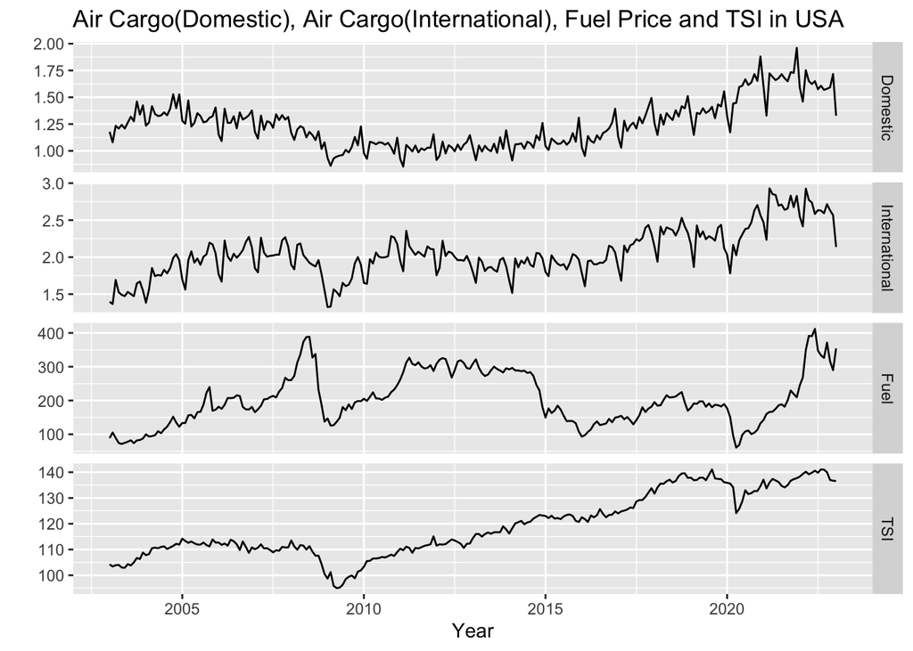

```r
#revenue_ts
autoplot(revenue_ts, facets=TRUE) +
  xlab("Year") + ylab("") +
  ggtitle("Air Cargo(Domestic), Air Cargo(International), Fuel Price and TSI in USA")
```

I have selected Air Cargo (Domestic), Air Cargo (International), Fuel Price, and TSI as variables for analysis. My objective is to explore the interdependencies among these variables. Specifically, I aim to understand whether there is a mutual influence between domestic and international air cargo, whether fuel prices affect air cargo volumes, and whether the TSI correlates with the other variables. By examining the relationships among these variables, I hope to gain insights into the dynamics of the air cargo industry and its drivers.

**Employment ~ Air Cargo(Domestic) + Air Cargo(International)**

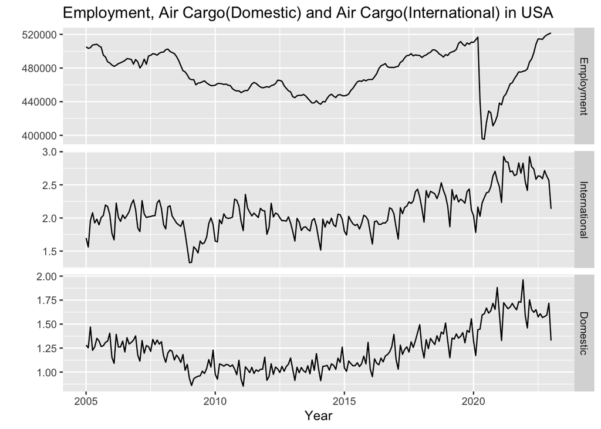

```r
#emp_ts
autoplot(emp_ts, facets=TRUE) +
  xlab("Year") + ylab("") +
  ggtitle("Employment, Air Cargo(Domestic) and Air Cargo(International) in USA")
```

I have selected Air Cargo (Domestic), Air Cargo (International), and Employment as variables for analysis. My goal is to examine the potential mutual influence among these variables. Specifically, I aim to understand whether changes in domestic and international air cargo volumes impact employment levels, and vice versa. This analysis will help me understand the interconnectedness of these factors and their implications for economic activity and employment trends.

**VAR: GDP ~ Revenue + Employment (Air)**

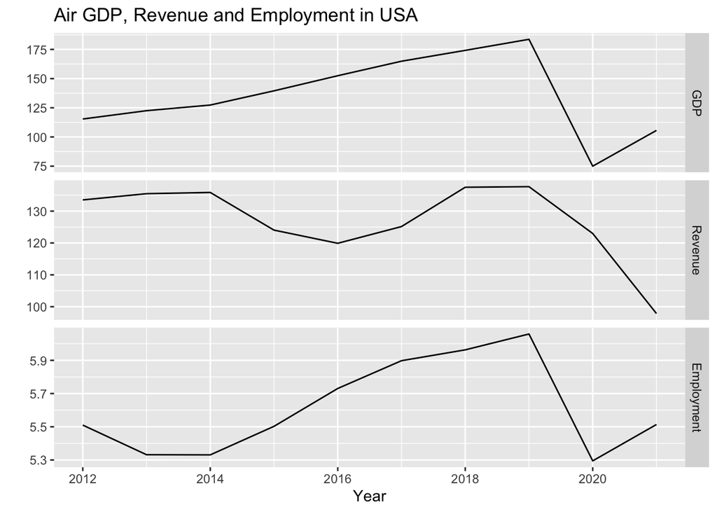

```r
#air_ts
autoplot(air_ts, facets=TRUE) +
  xlab("Year") + ylab("") +
  ggtitle("Air GDP, Revenue and Employment in USA")
```

My objective is to explore the potential interrelationships among these variables. Specifically, I aim to understand how changes in GDP and Revenue within the air industry may influence employment levels, and vice versa. By investigating the relationships among these key indicators, I seek to gain insights into the dynamics of the air industry’s economic performance and its impact on employment trends.

### Select Best VAR(p)

**Air Cargo(Domestic) ~ Air Cargo(International) + Fuel Price + TSI**

```r
#revenue_ts

VARselect(revenue_ts, lag.max=10, type="both")
```

```
$selection
AIC(n)  HQ(n)  SC(n) FPE(n)
    10      3      3     10

$criteria
                1          2           3           4           5           6
AIC(n) -1.7914947 -2.0213042 -2.59011953 -2.63469636 -2.64432332 -2.69497335
HQ(n)  -1.6472405 -1.7808805 -2.25352637 -2.20193372 -2.11539121 -2.06987177
SC(n)  -1.4338410 -1.4252145 -1.75559402 -1.56173499 -1.33292609 -1.14514027
FPE(n)  0.1667186  0.1325113  0.07505571  0.07183165  0.07121818  0.06780348
                 7           8          9          10
AIC(n) -2.71729130 -2.77094641 -2.8679699 -3.08122759
HQ(n)  -1.99602025 -1.95350588 -1.9543599 -2.07144811
SC(n)  -0.92902236 -0.74424161 -0.6028292 -0.57765108
FPE(n)  0.06644436  0.06314439  0.0575039  0.04665972
```

```r
summary(vars::VAR(revenue_ts, p=1, type='both'))
```

```
VAR Estimation Results:
=========================
Endogenous variables: Domestic, International, Fuel, TSI
Deterministic variables: both
Sample size: 240
Log Likelihood: -1115.26
Roots of the characteristic polynomial:
0.9713 0.9493 0.6821 0.6821
Call:
vars::VAR(y = revenue_ts, p = 1, type = "both")


Estimation results for equation Domestic:
=========================================
Domestic = Domestic.l1 + International.l1 + Fuel.l1 + TSI.l1 + const + trend

                   Estimate Std. Error t value Pr(>|t|)
Domestic.l1       0.6579380  0.0645703  10.189  < 2e-16 ***
International.l1  0.0692311  0.0492711   1.405  0.16132
Fuel.l1          -0.0002871  0.0001188  -2.416  0.01648 *
TSI.l1            0.0047247  0.0015653   3.018  0.00282 **
const            -0.1637126  0.1388310  -1.179  0.23951
trend            -0.0004562  0.0002529  -1.804  0.07259 .
---
Signif. codes:  0 '***' 0.001 '**' 0.01 '*' 0.05 '.' 0.1 ' ' 1


Residual standard error: 0.1109 on 234 degrees of freedom
Multiple R-Squared: 0.7496, Adjusted R-squared: 0.7442
F-statistic: 140.1 on 5 and 234 DF,  p-value: < 2.2e-16


Estimation results for equation International:
==============================================
International = Domestic.l1 + International.l1 + Fuel.l1 + TSI.l1 + const + trend

                   Estimate Std. Error t value Pr(>|t|)
Domestic.l1      -7.306e-02  9.349e-02  -0.781    0.435
International.l1  7.191e-01  7.134e-02  10.081   <2e-16 ***
Fuel.l1           6.131e-05  1.721e-04   0.356    0.722
```

[output cut: 51 more lines]

```


Covariance matrix of residuals:
              Domestic International     Fuel     TSI
Domestic       0.01231       0.01232  -0.1394 0.02611
International  0.01232       0.02580   0.2995 0.05176
Fuel          -0.13935       0.29948 396.9225 2.41270
TSI            0.02611       0.05176   2.4127 2.34903

Correlation matrix of residuals:
              Domestic International     Fuel     TSI
Domestic       1.00000       0.69107 -0.06304 0.15356
International  0.69107       1.00000  0.09358 0.21023
Fuel          -0.06304       0.09358  1.00000 0.07901
TSI            0.15356       0.21023  0.07901 1.00000
```

```r
summary(vars::VAR(revenue_ts, p=3, type='both'))
```

```
VAR Estimation Results:
=========================
Endogenous variables: Domestic, International, Fuel, TSI
Deterministic variables: both
Sample size: 238
Log Likelihood: -982.485
Roots of the characteristic polynomial:
0.9811 0.9539 0.8896 0.8896 0.7354 0.7354 0.6699 0.6699 0.3692 0.3692 0.3253 0.1988
Call:
vars::VAR(y = revenue_ts, p = 3, type = "both")


Estimation results for equation Domestic:
=========================================
Domestic = Domestic.l1 + International.l1 + Fuel.l1 + TSI.l1 + Domestic.l2 + International.l2 + Fuel.l2 + TSI.l2 + Domestic.l3 + International.l3 + Fuel.l3 + TSI.l3 + const + trend

                   Estimate Std. Error t value Pr(>|t|)
Domestic.l1      -8.302e-03  7.359e-02  -0.113   0.9103
International.l1  2.927e-01  4.848e-02   6.038 6.41e-09 ***
Fuel.l1          -2.777e-04  2.864e-04  -0.970   0.3333
TSI.l1           -8.575e-03  3.657e-03  -2.345   0.0199 *
Domestic.l2       1.100e-01  7.515e-02   1.463   0.1448
International.l2  8.956e-02  5.503e-02   1.627   0.1051
Fuel.l2           7.788e-04  4.362e-04   1.785   0.0755 .
TSI.l2            3.346e-03  4.821e-03   0.694   0.4883
Domestic.l3       8.158e-01  7.347e-02  11.104  < 2e-16 ***
International.l3 -4.075e-01  4.852e-02  -8.397 5.25e-15 ***
Fuel.l3          -6.434e-04  2.985e-04  -2.156   0.0322 *
TSI.l3            6.501e-03  3.571e-03   1.821   0.0700 .
const             2.351e-02  1.054e-01   0.223   0.8237
trend             8.982e-05  1.962e-04   0.458   0.6475
---
Signif. codes:  0 '***' 0.001 '**' 0.01 '*' 0.05 '.' 0.1 ' ' 1


Residual standard error: 0.08101 on 224 degrees of freedom
Multiple R-Squared: 0.8719, Adjusted R-squared: 0.8645
F-statistic: 117.3 on 13 and 224 DF,  p-value: < 2.2e-16


```

[output cut: 83 more lines]

```


Covariance matrix of residuals:
               Domestic International     Fuel     TSI
Domestic       0.006562      0.005779  -0.1260 0.01196
International  0.005779      0.016288   0.1116 0.02800
Fuel          -0.126009      0.111580 377.3863 1.23452
TSI            0.011962      0.028003   1.2345 2.17053

Correlation matrix of residuals:
              Domestic International     Fuel     TSI
Domestic       1.00000        0.5589 -0.08007 0.10023
International  0.55895        1.0000  0.04500 0.14893
Fuel          -0.08007        0.0450  1.00000 0.04313
TSI            0.10023        0.1489  0.04313 1.00000
```

```r
summary(vars::VAR(revenue_ts, p=10, type='both'))
```

```
VAR Estimation Results:
=========================
Endogenous variables: Domestic, International, Fuel, TSI
Deterministic variables: both
Sample size: 231
Log Likelihood: -787.217
Roots of the characteristic polynomial:
0.9895 0.9895 0.9664 0.9664 0.9573 0.9573 0.9568 0.9568 0.9562 0.9562 0.946 0.946 0.9254 0.9074 0.9074 0.8791 0.8791 0.8471 0.8471 0.8458 0.8458 0.8411 0.8411 0.8284 0.8284 0.827 0.827 0.8105 0.7963 0.7963 0.7884 0.7884 0.7835 0.7835 0.7624 0.7624 0.518 0.4269 0.4269 0.0279
Call:
vars::VAR(y = revenue_ts, p = 10, type = "both")


Estimation results for equation Domestic:
=========================================
Domestic = Domestic.l1 + International.l1 + Fuel.l1 + TSI.l1 + Domestic.l2 + International.l2 + Fuel.l2 + TSI.l2 + Domestic.l3 + International.l3 + Fuel.l3 + TSI.l3 + Domestic.l4 + International.l4 + Fuel.l4 + TSI.l4 + Domestic.l5 + International.l5 + Fuel.l5 + TSI.l5 + Domestic.l6 + International.l…

                    Estimate Std. Error t value Pr(>|t|)
Domestic.l1        6.744e-02  8.081e-02   0.835 0.405005
International.l1   3.114e-01  5.516e-02   5.644 5.99e-08 ***
Fuel.l1            1.953e-04  2.750e-04   0.710 0.478497
TSI.l1            -1.069e-02  3.623e-03  -2.950 0.003583 **
Domestic.l2       -6.736e-03  8.072e-02  -0.083 0.933583
International.l2  -1.880e-02  6.564e-02  -0.286 0.774861
Fuel.l2            4.754e-04  4.067e-04   1.169 0.243973
TSI.l2             6.340e-03  4.571e-03   1.387 0.167082
Domestic.l3        7.875e-01  8.465e-02   9.302  < 2e-16 ***
International.l3  -2.491e-01  6.332e-02  -3.934 0.000117 ***
Fuel.l3           -6.193e-04  4.054e-04  -1.528 0.128228
TSI.l3            -2.390e-03  4.612e-03  -0.518 0.604929
Domestic.l4       -8.394e-02  1.026e-01  -0.818 0.414297
International.l4  -6.442e-02  6.510e-02  -0.990 0.323684
Fuel.l4           -1.774e-04  4.274e-04  -0.415 0.678567
TSI.l4             3.052e-03  4.751e-03   0.642 0.521399
Domestic.l5        1.703e-01  1.025e-01   1.661 0.098308 .
International.l5   6.475e-02  6.831e-02   0.948 0.344380
Fuel.l5            9.421e-04  4.325e-04   2.178 0.030631 *
TSI.l5            -1.930e-04  4.635e-03  -0.042 0.966830
Domestic.l6       -2.293e-01  1.013e-01  -2.263 0.024756 *
International.l6  -9.264e-02  6.831e-02  -1.356 0.176633
Fuel.l6           -3.856e-04  4.415e-04  -0.873 0.383609
```

[output cut: 195 more lines]

```


Covariance matrix of residuals:
               Domestic International       Fuel      TSI
Domestic       0.004799      0.004927  -0.027522 0.006024
International  0.004927      0.012574  -0.002224 0.028267
Fuel          -0.027522     -0.002224 348.316937 2.527075
TSI            0.006024      0.028267   2.527075 1.995426

Correlation matrix of residuals:
              Domestic International      Fuel     TSI
Domestic       1.00000      0.634273 -0.021287 0.06155
International  0.63427      1.000000 -0.001063 0.17845
Fuel          -0.02129     -0.001063  1.000000 0.09585
TSI            0.06155      0.178454  0.095855 1.00000
```

**Employment ~ Air Cargo(Domestic) + Air Cargo(International)**

```r
#emp_ts


VARselect(emp_ts, lag.max=10, type="both")
```

```
$selection
AIC(n)  HQ(n)  SC(n) FPE(n)
    10      4      3     10

$criteria
                 1           2           3           4           5           6
AIC(n)    9.110946    8.773224    7.963614    7.900765    7.930169    7.954179
HQ(n)     9.208607    8.929482    8.178469    8.174216    8.262217    8.344823
SC(n)     9.352448    9.159626    8.494917    8.576969    8.751274    8.920185
FPE(n) 9054.112803 6459.709303 2875.307462 2701.022106 2782.990414 2852.620477
                 7           8           9          10
AIC(n)    7.989814    7.939700    7.745777    7.566330
HQ(n)     8.439055    8.447538    8.312211    8.191361
SC(n)     9.100720    9.195508    9.146485    9.111939
FPE(n) 2958.915419 2817.771246 2324.690271 1946.575388
```

```r
summary(vars::VAR(emp_ts, p=1, type='both'))
```

```
VAR Estimation Results:
=========================
Endogenous variables: Employment, International, Domestic
Deterministic variables: both
Sample size: 216
Log Likelihood: -1889.312
Roots of the characteristic polynomial:
0.9571 0.7598 0.675
Call:
vars::VAR(y = emp_ts, p = 1, type = "both")


Estimation results for equation Employment:
===========================================
Employment = Employment.l1 + International.l1 + Domestic.l1 + const + trend

                   Estimate Std. Error t value Pr(>|t|)
Employment.l1     9.573e-01  2.031e-02  47.127   <2e-16 ***
International.l1  5.940e+03  3.065e+03   1.938   0.0539 .
Domestic.l1      -2.827e+03  3.993e+03  -0.708   0.4797
const             1.174e+04  9.453e+03   1.242   0.2155
trend            -3.231e+00  1.004e+01  -0.322   0.7479
---
Signif. codes:  0 '***' 0.001 '**' 0.01 '*' 0.05 '.' 0.1 ' ' 1


Residual standard error: 7005 on 211 degrees of freedom
Multiple R-Squared: 0.923,  Adjusted R-squared: 0.9216
F-statistic: 632.5 on 4 and 211 DF,  p-value: < 2.2e-16


Estimation results for equation International:
==============================================
International = Employment.l1 + International.l1 + Domestic.l1 + const + trend

                  Estimate Std. Error t value Pr(>|t|)
Employment.l1    1.304e-07  4.809e-07   0.271  0.78648
International.l1 7.150e-01  7.255e-02   9.856  < 2e-16 ***
Domestic.l1      3.018e-02  9.452e-02   0.319  0.74984
const            4.149e-01  2.238e-01   1.854  0.06515 .
```

[output cut: 26 more lines]

```
F-statistic: 161.8 on 4 and 211 DF,  p-value: < 2.2e-16



Covariance matrix of residuals:
              Employment International Domestic
Employment     4.907e+07     137.91323 19.57489
International  1.379e+02       0.02750  0.01333
Domestic       1.957e+01       0.01333  0.01291

Correlation matrix of residuals:
              Employment International Domestic
Employment       1.00000        0.1187  0.02459
International    0.11873        1.0000  0.70741
Domestic         0.02459        0.7074  1.00000
```

```r
summary(vars::VAR(emp_ts, p=3, type='both'))
```

```
VAR Estimation Results:
=========================
Endogenous variables: Employment, International, Domestic
Deterministic variables: both
Sample size: 214
Log Likelihood: -1736.085
Roots of the characteristic polynomial:
0.975 0.8715 0.8715 0.7398 0.7398 0.6188 0.6188 0.5663 0.5663
Call:
vars::VAR(y = emp_ts, p = 3, type = "both")


Estimation results for equation Employment:
===========================================
Employment = Employment.l1 + International.l1 + Domestic.l1 + Employment.l2 + International.l2 + Domestic.l2 + Employment.l3 + International.l3 + Domestic.l3 + const + trend

                   Estimate Std. Error t value Pr(>|t|)
Employment.l1     1.425e+00  6.803e-02  20.944  < 2e-16 ***
International.l1  1.666e+03  3.721e+03   0.448   0.6548
Domestic.l1      -1.269e+04  5.778e+03  -2.197   0.0292 *
Employment.l2    -7.481e-01  1.097e-01  -6.817 1.04e-10 ***
International.l2  8.677e+03  4.274e+03   2.030   0.0437 *
Domestic.l2       1.520e+03  5.926e+03   0.256   0.7978
Employment.l3     2.702e-01  6.791e-02   3.978 9.67e-05 ***
International.l3 -3.540e+03  3.660e+03  -0.967   0.3346
Domestic.l3       9.636e+03  5.614e+03   1.716   0.0876 .
const             1.385e+04  8.805e+03   1.573   0.1172
trend            -8.734e+00  9.378e+00  -0.931   0.3527
---
Signif. codes:  0 '***' 0.001 '**' 0.01 '*' 0.05 '.' 0.1 ' ' 1


Residual standard error: 6140 on 203 degrees of freedom
Multiple R-Squared: 0.9423, Adjusted R-squared: 0.9395
F-statistic: 331.6 on 10 and 203 DF,  p-value: < 2.2e-16


Estimation results for equation International:
==============================================
International = Employment.l1 + International.l1 + Domestic.l1 + Employment.l2 + International.l2 + Domestic.l2 + Employment.l3 + International.l3 + Domestic.l3 + const + trend
```

[output cut: 44 more lines]

```
F-statistic: 163.2 on 10 and 203 DF,  p-value: < 2.2e-16



Covariance matrix of residuals:
              Employment International   Domestic
Employment     3.771e+07     75.964305 -24.526455
International  7.596e+01      0.016127   0.005081
Domestic      -2.453e+01      0.005081   0.006009

Correlation matrix of residuals:
              Employment International Domestic
Employment       1.00000       0.09742 -0.05153
International    0.09742       1.00000  0.51617
Domestic        -0.05153       0.51617  1.00000
```

```r
summary(vars::VAR(emp_ts, p=4, type='both'))
```

```
VAR Estimation Results:
=========================
Endogenous variables: Employment, International, Domestic
Deterministic variables: both
Sample size: 213
Log Likelihood: -1706.444
Roots of the characteristic polynomial:
0.9763 0.9302 0.9302 0.761 0.761 0.6724 0.6713 0.6713 0.6339 0.6339 0.1615 0.1615
Call:
vars::VAR(y = emp_ts, p = 4, type = "both")


Estimation results for equation Employment:
===========================================
Employment = Employment.l1 + International.l1 + Domestic.l1 + Employment.l2 + International.l2 + Domestic.l2 + Employment.l3 + International.l3 + Domestic.l3 + Employment.l4 + International.l4 + Domestic.l4 + const + trend

                   Estimate Std. Error t value Pr(>|t|)
Employment.l1     1.411e+00  7.090e-02  19.895  < 2e-16 ***
International.l1  4.118e+03  4.002e+03   1.029   0.3048
Domestic.l1      -1.208e+04  6.574e+03  -1.837   0.0677 .
Employment.l2    -6.834e-01  1.232e-01  -5.548 9.12e-08 ***
International.l2  6.302e+03  4.907e+03   1.284   0.2005
Domestic.l2       4.196e+03  6.478e+03   0.648   0.5179
Employment.l3     1.685e-01  1.233e-01   1.367   0.1731
International.l3 -3.935e+03  4.389e+03  -0.896   0.3711
Domestic.l3       1.348e+04  6.116e+03   2.204   0.0287 *
Employment.l4     5.606e-02  7.074e-02   0.793   0.4290
International.l4  1.482e+03  4.371e+03   0.339   0.7349
Domestic.l4      -9.306e+03  7.856e+03  -1.185   0.2376
const             1.159e+04  9.046e+03   1.281   0.2015
trend            -7.188e+00  9.658e+00  -0.744   0.4576
---
Signif. codes:  0 '***' 0.001 '**' 0.01 '*' 0.05 '.' 0.1 ' ' 1


Residual standard error: 6124 on 199 degrees of freedom
Multiple R-Squared: 0.9433, Adjusted R-squared: 0.9396
F-statistic: 254.5 on 13 and 199 DF,  p-value: < 2.2e-16


```

[output cut: 53 more lines]

```
F-statistic: 126.6 on 13 and 199 DF,  p-value: < 2.2e-16



Covariance matrix of residuals:
              Employment International  Domestic
Employment     3.750e+07      74.24409 -20.44733
International  7.424e+01       0.01529   0.00550
Domestic      -2.045e+01       0.00550   0.00598

Correlation matrix of residuals:
              Employment International Domestic
Employment       1.00000       0.09805 -0.04318
International    0.09805       1.00000  0.57527
Domestic        -0.04318       0.57527  1.00000
```

**VAR: GDP ~ Revenue + Employment (Air)**

```r
#air_ts

VARselect(air_ts, lag.max=5, type="both")
```

```
$selection
AIC(n)  HQ(n)  SC(n) FPE(n)
     1      1      1      2

$criteria
          1    2    3    4    5
AIC(n) -Inf -Inf -Inf -Inf -Inf
HQ(n)  -Inf -Inf -Inf -Inf -Inf
SC(n)  -Inf -Inf -Inf -Inf -Inf
FPE(n)  NaN    0    0    0    0
```

```r
summary(vars::VAR(air_ts, p=1, type='both'))
```

```
VAR Estimation Results:
=========================
Endogenous variables: GDP, Revenue, Employment
Deterministic variables: both
Sample size: 9
Log Likelihood: -24.465
Roots of the characteristic polynomial:
0.9637 0.9637 0.1452
Call:
vars::VAR(y = air_ts, p = 1, type = "both")


Estimation results for equation GDP:
====================================
GDP = GDP.l1 + Revenue.l1 + Employment.l1 + const + trend

              Estimate Std. Error t value Pr(>|t|)
GDP.l1          0.7536     1.1871   0.635    0.560
Revenue.l1     -2.4272     2.1730  -1.117    0.327
Employment.l1 -33.5100   148.2595  -0.226    0.832
const         557.4928   721.3612   0.773    0.483
trend          -3.2764     7.2385  -0.453    0.674


Residual standard error: 40.1 on 4 degrees of freedom
Multiple R-Squared: 0.3371, Adjusted R-squared: -0.3259
F-statistic: 0.5085 on 4 and 4 DF,  p-value: 0.7357


Estimation results for equation Revenue:
========================================
Revenue = GDP.l1 + Revenue.l1 + Employment.l1 + const + trend

                Estimate Std. Error t value Pr(>|t|)
GDP.l1          0.006165   0.225900   0.027   0.9795
Revenue.l1      0.276354   0.413499   0.668   0.5405
Employment.l1  32.531561  28.211972   1.153   0.3131
const         -70.219995 137.266254  -0.512   0.6359
trend          -3.888946   1.377392  -2.823   0.0477 *
---
```

[output cut: 22 more lines]

```
F-statistic: 0.9605 on 4 and 4 DF,  p-value: 0.5151



Covariance matrix of residuals:
              GDP Revenue Employment
GDP        1607.9  227.80   11.90347
Revenue     227.8   58.22    1.55021
Employment   11.9    1.55    0.08885

Correlation matrix of residuals:
              GDP Revenue Employment
GDP        1.0000  0.7445     0.9959
Revenue    0.7445  1.0000     0.6816
Employment 0.9959  0.6816     1.0000
```

```r
#summary(vars::VAR(air_ts, p=2, type='both'))
```

### Cross Validation

**Air Cargo(Domestic) ~ Air Cargo(International) + Fuel Price + TSI**

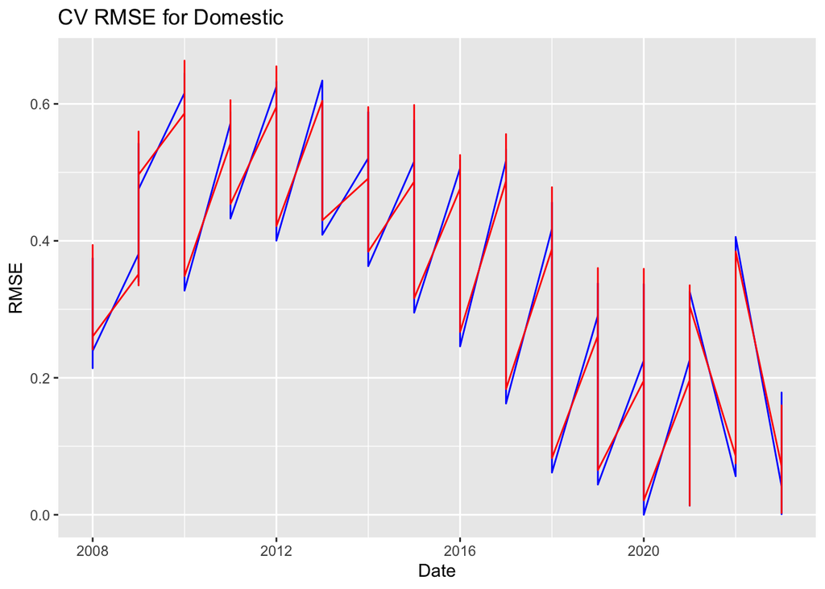

```r
#revenue_ts

n=240
k=48 #12*4

#n-k=192; 192/12=16;

rmse1 <- matrix(NA, 192,4) #here is n-k
rmse2 <- matrix(NA, 192,4)
rmse3 <- matrix(NA,16,12) #here n-k / 12
year<-c()

ts_obj1 <- head(revenue_ts, -1)

st <- tsp(ts_obj1 )[1]+(k-1)/12


for(i in 1:16) #here  is (n-k ) / 12
{

  xtrain <- window(ts_obj1, end=st + i-1)
  xtest <- window(ts_obj1, start=st + (i-1) + 1/12, end=st + i)

  ######## first Model ############
  fit <- vars::VAR(ts_obj1, p=4, type='both')
  fcast <- predict(fit, n.ahead = 12)
  fdo<-fcast$fcst$Domestic
  fin<-fcast$fcst$International
  ffuel<-fcast$fcst$Fuel
  ftsi <-fcast$fcst$TSI

  ff<-data.frame(fdo[,1],fin[,1],ffuel[,1],ftsi[,1]) #collecting the forecasts for 4 variables

  year<-st + (i-1) + 1/12 #starting year

  ####### convert to a time series object ########

  ff<-ts(ff,start=c(year,1),frequency = 12)

  a = 12*i-11 #going from 1,13, 15, (1,1+12,1+12+12, 1+12+12+12, ...)
  b= 12*i #12, 24, 36

  ##### collecting errors ######
  rmse1[c(a:b),]  <-sqrt((ff-xtest)^2)


  ######## Second Model ############
  fit2 <- vars::VAR(ts_obj1, p=3, type='both')
  fcast2 <- predict(fit2, n.ahead = 12)

  fdo<-fcast2$fcst$Domestic
  fin<-fcast2$fcst$International
  ffuel<-fcast2$fcst$Fuel
  ftsi <-fcast2$fcst$TSI

  ff2<-data.frame(fdo[,1],fin[,1],ffuel[,1],ftsi[,1])

  year<-st + (i-1) + 1/12

  ff2<-ts(ff2,start=c(year,1),frequency = 12)

  a = 12*i-11
  b= 12*i
  rmse2[c(a:b),]  <-sqrt((ff2-xtest)^2)
}

yr = rep(c(2008:2023),each =12) #year
qr = rep(paste0("M",1:12),16) #monthly

rmse1 = data.frame(yr,qr,rmse1)
names(rmse1) =c("Year", "Month", "Domestic", "International", "Fuel", "TSI")
rmse2 = data.frame(yr,qr,rmse2)
names(rmse2) =c("Year", "Month", "Domestic", "International", "Fuel", "TSI")

ggplot() +
  geom_line(data = rmse1, aes(x = Year, y = Domestic),color = "blue") +
  geom_line(data = rmse2, aes(x = Year, y = Domestic),color = "red") +
  labs(
    title = "CV RMSE for Domestic",
    x = "Date",
    y = "RMSE",
    guides(colour=guide_legend(title="Fit")))
```

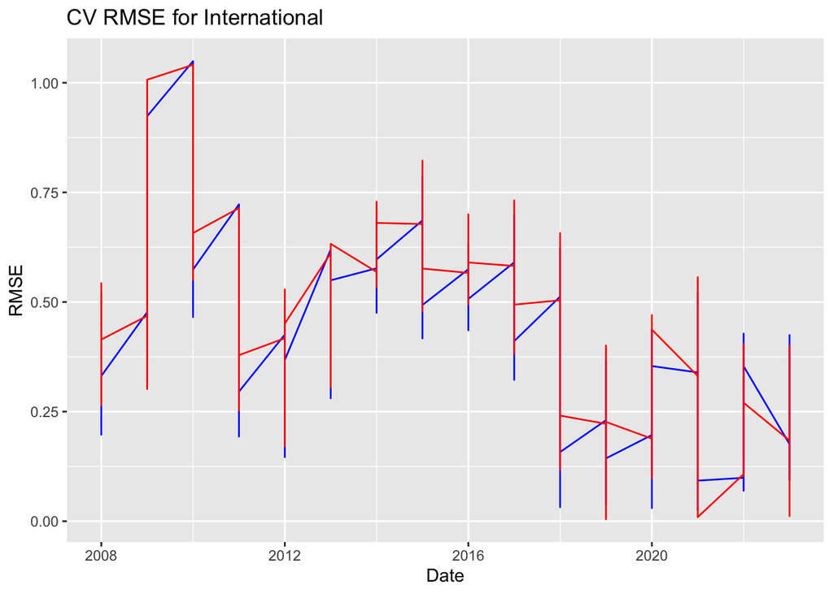

```r
ggplot() +
  geom_line(data = rmse1, aes(x = Year, y = International),color = "blue") +
  geom_line(data = rmse2, aes(x = Year, y = International),color = "red") +
  labs(
    title = "CV RMSE for International",
    x = "Date",
    y = "RMSE",
    guides(colour=guide_legend(title="Fit")))
```

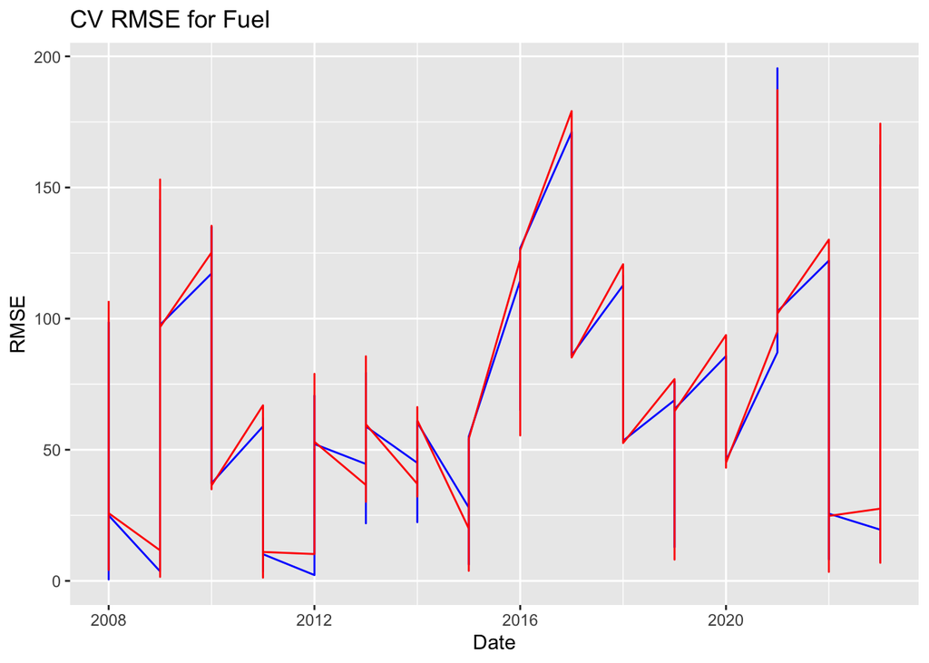

```r
ggplot() +
  geom_line(data = rmse1, aes(x = Year, y = Fuel),color = "blue") +
  geom_line(data = rmse2, aes(x = Year, y = Fuel),color = "red") +
  labs(
    title = "CV RMSE for Fuel",
    x = "Date",
    y = "RMSE",
    guides(colour=guide_legend(title="Fit")))
```

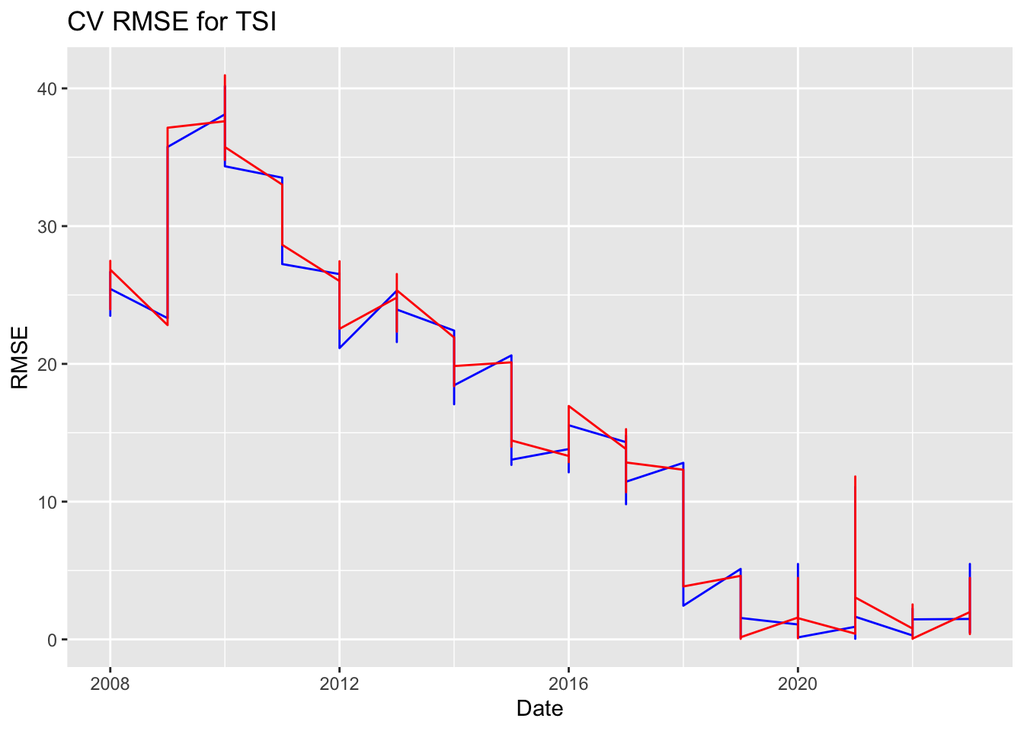

```r
ggplot() +
  geom_line(data = rmse1, aes(x = Year, y = TSI),color = "blue") +
  geom_line(data = rmse2, aes(x = Year, y = TSI),color = "red") +
  labs(
    title = "CV RMSE for TSI",
    x = "Date",
    y = "RMSE",
    guides(colour=guide_legend(title="Fit")))
```

**Employment ~ Air Cargo(Domestic) + Air Cargo(International)**

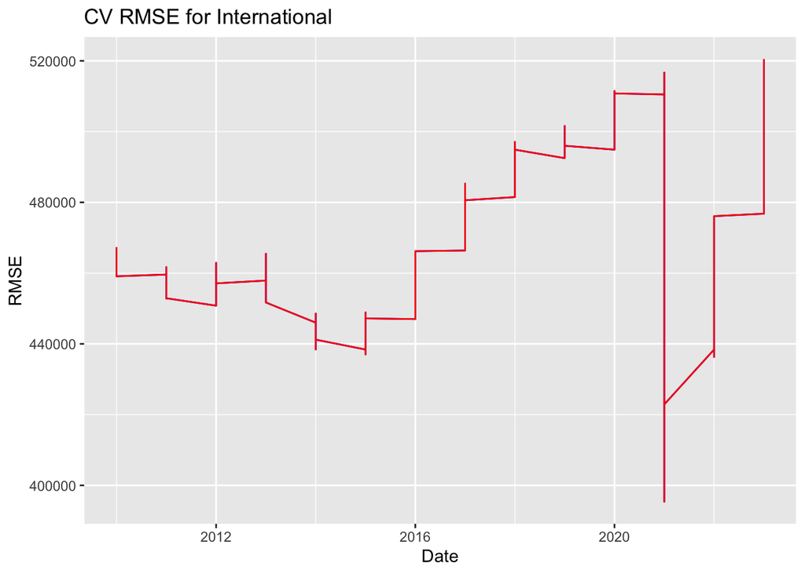

```r
#emp_ts
n=217
k=48 #12*4

#n-k=168; 168/12=14;

rmse1 <- matrix(NA, 168,3) #here is n-k
rmse2 <- matrix(NA, 168,3)
rmse3 <- matrix(NA,14,12) #here n-k / 12
year<-c()

ts_obj2 <- head(emp_ts, -1)

st <- tsp(ts_obj2 )[1]+(k-1)/12


for(i in 1:14) #here  is (n-k ) / 12
{

  xtrain <- window(ts_obj2, end=st + i-1)
  xtest <- window(ts_obj2, start=st + (i-1) + 1/12, end=st + i)

  ######## first Model ############
  fit <- vars::VAR(ts_obj2, p=3, type='both')
  fcast <- predict(fit, n.ahead = 12)
  fin<-fcast$fcst$International
  fdo<-fcast$fcst$Domestic
  femp<-fcast$fcst$Employment

  ff<-data.frame(fin[,1],fdo[,1],femp[,1]) #collecting the forecasts for 3 variables

  year<-st + (i-1) + 1/12 #starting year

  ####### convert to a time series object ########

  ff<-ts(ff,start=c(year,1),frequency = 12)

  a = 12*i-11 #going from 1,13, 15, (1,1+12,1+12+12, 1+12+12+12, ...)
  b= 12*i #12, 24, 36

  ##### collecting errors ######
  rmse1[c(a:b),]  <-sqrt((ff-xtest)^2)


  ######## Second Model ############
  fit2 <- vars::VAR(ts_obj2, p=4, type='both')
  fcast2 <- predict(fit2, n.ahead = 12)

  fin<-fcast2$fcst$International
  fdo<-fcast2$fcst$Domestic
  femp<-fcast2$fcst$Employment
  ff2<-data.frame(fin[,1],fdo[,1],femp[,1])

  year<-st + (i-1) + 1/12

  ff2<-ts(ff2,start=c(year,1),frequency = 12)

  a = 12*i-11
  b= 12*i
  rmse2[c(a:b),]  <-sqrt((ff2-xtest)^2)
}

yr = rep(c(2010:2023),each =12) #year
qr = rep(paste0("M",1:12),14) #monthly

rmse1 = data.frame(yr,qr,rmse1)
names(rmse1) =c("Year", "Month","International","Domestic","Employment")
rmse2 = data.frame(yr,qr,rmse2)
names(rmse2) =c("Year", "Month","International","Domestic","Employment")

ggplot() +
  geom_line(data = rmse1, aes(x = Year, y = International),color = "blue") +
  geom_line(data = rmse2, aes(x = Year, y = International),color = "red") +
  labs(
    title = "CV RMSE for International",
    x = "Date",
    y = "RMSE",
    guides(colour=guide_legend(title="Fit")))
```

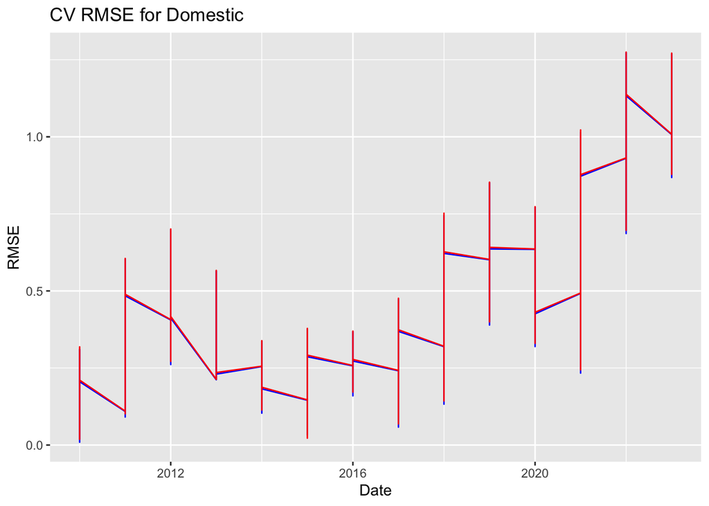

```r
ggplot() +
  geom_line(data = rmse1, aes(x = Year, y = Domestic),color = "blue") +
  geom_line(data = rmse2, aes(x = Year, y = Domestic),color = "red") +
  labs(
    title = "CV RMSE for Domestic",
    x = "Date",
    y = "RMSE",
    guides(colour=guide_legend(title="Fit")))
```

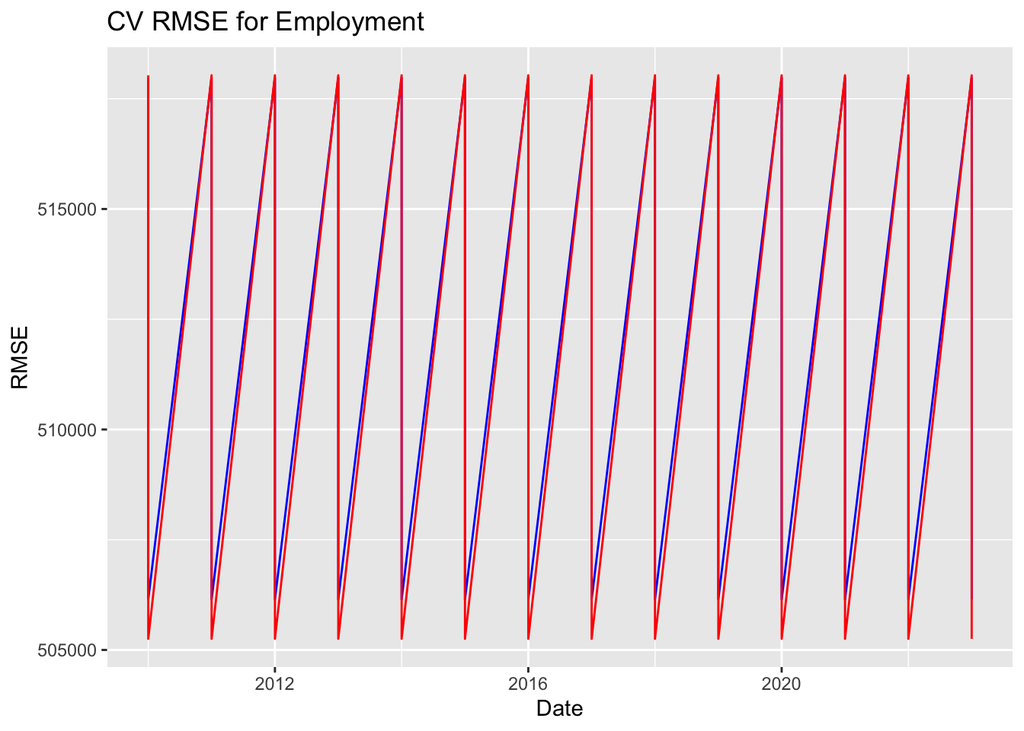

```r
ggplot() +
  geom_line(data = rmse1, aes(x = Year, y = Employment),color = "blue") +
  geom_line(data = rmse2, aes(x = Year, y = Employment),color = "red") +
  labs(
    title = "CV RMSE for Employment",
    x = "Date",
    y = "RMSE",
    guides(colour=guide_legend(title="Fit")))
```

**VAR: GDP ~ Revenue + Employment (Air)**

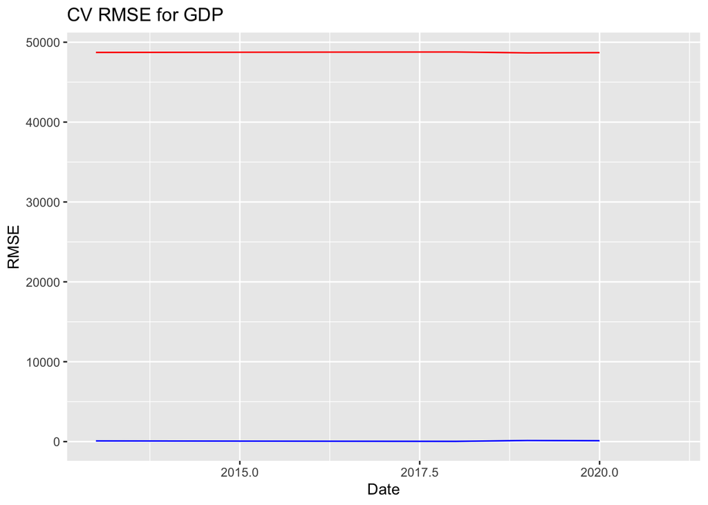

```r
#air_ts
n=10 #372
k=1 #12*4

#n-k=9;

rmse1 <- matrix(NA, 9,3) #here is n-k
rmse2 <- matrix(NA, 9,3)
rmse3 <- matrix(NA,9) #here n-k
year<-c()

ts_obj <- air_ts

st <- tsp(ts_obj )[1]


for(i in 1:9) #here  is (n-k )
{

  xtrain <- window(ts_obj, end=st + i-1)
  xtest <- window(ts_obj, start=st + (i-1) + 1, end=st + i)

  ######## first Model ############
  fit <- vars::VAR(ts_obj, p=1, type='both')
  fcast <- predict(fit, n.ahead = 3)
  fgdp<-fcast$fcst$GDP
  fre<-fcast$fcst$Revenue
  femp<-fcast$fcst$Employment

  ff<-data.frame(fgdp[,1],fre[,1],femp[,1]) #collecting the forecasts for 3 variables

  year<-st + (i-1) #starting year

  ####### convert to a time series object ########

  ff<-ts(ff,start=c(year,1),frequency = 1)

  ##### collecting errors ######
  rmse1[i-1,]  <-sqrt((ff-xtest)^2)


  ######## Second Model ############
  fit2 <- vars::VAR(ts_obj, p=2, type='both')
  fcast2 <- predict(fit2, n.ahead = 3)

  fgdp<-fcast2$fcst$GDP
  fre<-fcast2$fcst$Revenue
  femp<-fcast2$fcst$Employment
  ff2<-data.frame(fgdp[,1],fre[,1],femp[,1])

  year<-st + (i-1)

  ff2<-ts(ff2,start=c(year,1),frequency = 1)

  rmse2[i-1,]  <-sqrt((ff2-xtest)^2)
}

yr = rep(c(2013:2021),each =1) #year

rmse1 = data.frame(yr,rmse1)
names(rmse1) =c("Year", "GDP","Revenue","Employment")
rmse2 = data.frame(yr,rmse2)
names(rmse2) =c("Year", "GDP","Revenue","Employment")

ggplot() +
  geom_line(data = rmse1, aes(x = Year, y = GDP),color = "blue") +
  geom_line(data = rmse2, aes(x = Year, y = GDP),color = "red") +
  labs(
    title = "CV RMSE for GDP",
    x = "Date",
    y = "RMSE",
    guides(colour=guide_legend(title="Fit")))
```

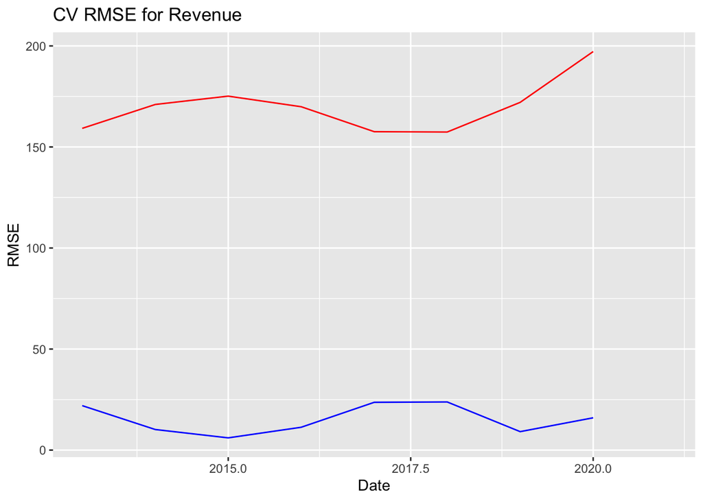

```r
ggplot() +
  geom_line(data = rmse1, aes(x = Year, y = Revenue),color = "blue") +
  geom_line(data = rmse2, aes(x = Year, y = Revenue),color = "red") +
  labs(
    title = "CV RMSE for Revenue",
    x = "Date",
    y = "RMSE",
    guides(colour=guide_legend(title="Fit")))
```

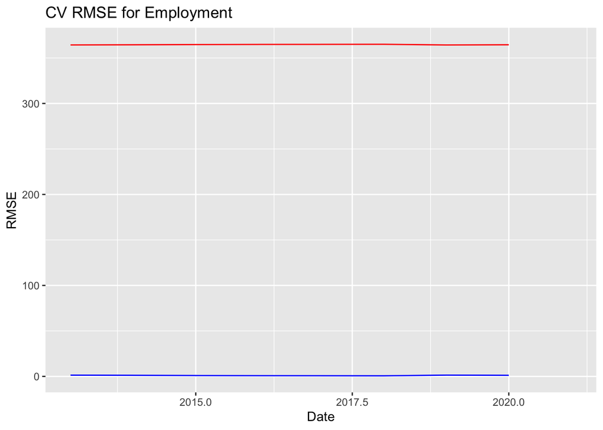

```r
ggplot() +
  geom_line(data = rmse1, aes(x = Year, y = Employment),color = "blue") +
  geom_line(data = rmse2, aes(x = Year, y = Employment),color = "red") +
  labs(
    title = "CV RMSE for Employment",
    x = "Date",
    y = "RMSE",
    guides(colour=guide_legend(title="Fit")))
```

Based on cross-validation results, it was found that the VAR(1) model exhibits a lower RMSE compared to the VAR(2) model. This lower RMSE indicates that the VAR(1) model provides better predictive performance and is therefore considered the superior model in this context.

### Forecast and Findings

**Air Cargo(Domestic) ~ Air Cargo(International) + Fuel Price + TSI**

The most optimal model I fitted is the VAR(3) model.

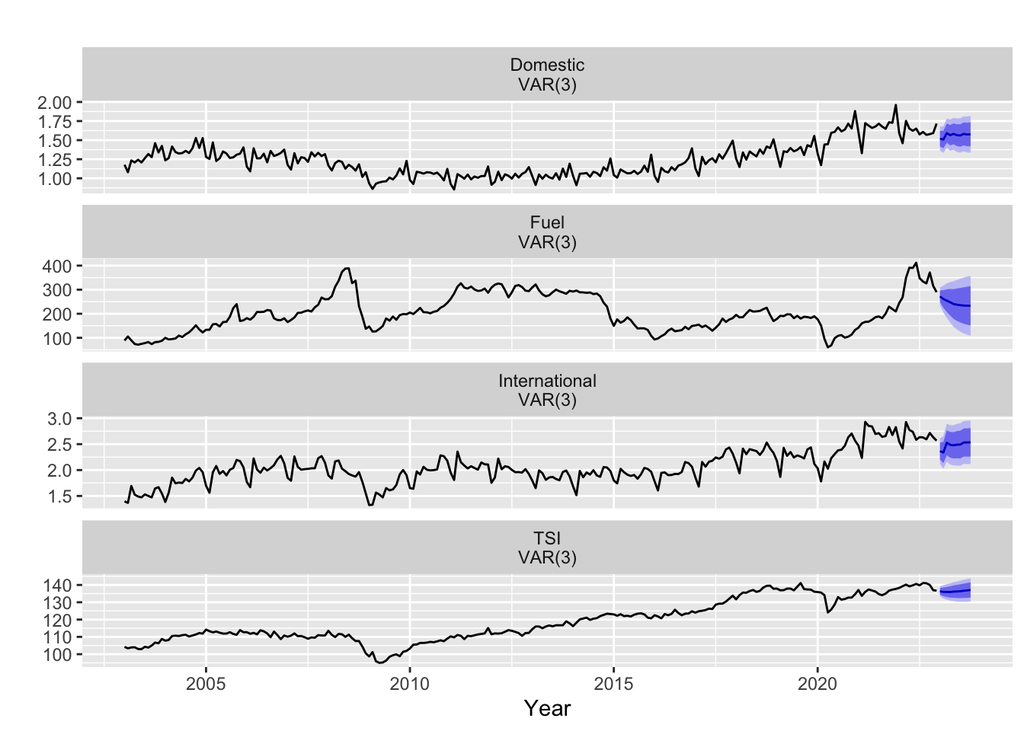

```r
#revenue_ts
var <- vars::VAR(ts_obj1, p=3, type='both')

forecast(var) %>%
  autoplot() + xlab("Year")
```

The forecast of the variables appears to capture the trend of the original data adequately. While the fuel trend shows a slight decrease, the trends in other variables appear relatively stable or flat. Furthermore, the model seems to struggle in capturing the seasonality present in the data.

**Employment ~ Air Cargo(Domestic) + Air Cargo(International)**

The most optimal model I fitted is the VAR(4) model.

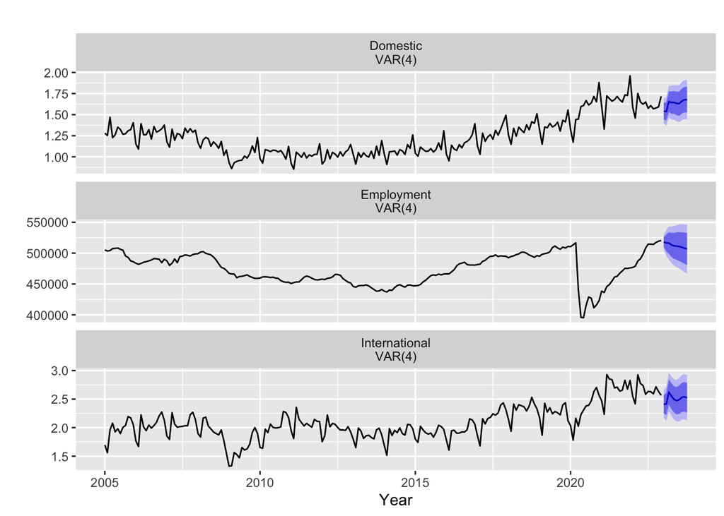

```r
#emp_ts
var <- vars::VAR(ts_obj2, p=4, type='both')

forecast(var) %>%
  autoplot() + xlab("Year")
```

The forecast of the variables appears to capture the trend of the original data adequately. While the employment trend shows a decreasing trend, the trends in other variables exhibit fluctuations, with an initial increase followed by a subsequent drop. However, it seems that the model struggles to capture the seasonality present in the data.

**VAR: GDP ~ Revenue + Employment (Air)**

The most optimal model I fitted is the VAR(1) model.

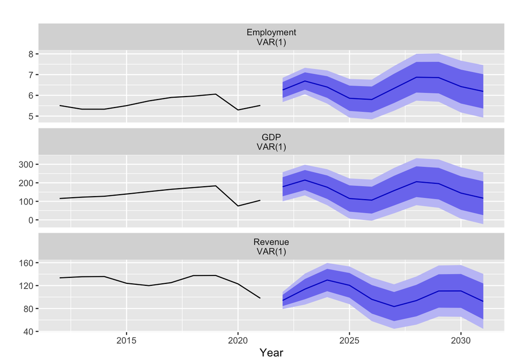

```r
#air_ts
var <- vars::VAR(ts_obj, p=1, type='both')

forecast(var) %>%
  autoplot() + xlab("Year")
```

The forecast of the variables does not appear to capture the trend of the original data adequately. All the variables exhibit fluctuations, characterized by an initial increase followed by a subsequent drop, which repeats over time. Additionally, the model diagnostics show no significant correlation among the variables, suggesting that the model performance may not be optimal.

### Findings

The first model appears to capture the trend of the original data adequately. While the fuel trend shows a slight decrease, the trends in other variables appear relatively stable or flat. Furthermore, the model seems to struggle in capturing the seasonality present in the data.

The second model appears to capture the trend of the original data adequately. While the employment trend shows a decreasing trend, the trends in other variables exhibit fluctuations, with an initial increase followed by a subsequent drop. However, it seems that the model struggles to capture the seasonality present in the data.

The third model does not appear to capture the trend of the original data adequately. All the variables exhibit fluctuations, characterized by an initial increase followed by a subsequent drop, which repeats over time. Additionally, the model diagnostics show no significant correlation among the variables, suggesting that the model performance may not be optimal.

Back to top